# e-statをRでたたいてみる

Hijiyama.R #4

kazutan

2016年5月28日

# 今回のお話

- e-statはAPIを公開
  - Webで簡単に登録可能
- たくさんのデータが公開されている
  - 自力で探してDLして読み込むのは面倒
- だったらもうRでやるしかないですね
  - estatapiパッケージを利用
  - このパッケージの使い方については以下のQiita記事を参照
  - [estatapiパッケージで簡単にe-Statのデータ取得](http://qiita.com/kazutan/items/9c0b2dd0f055fde45cda)

# 今回の流れ

- e-statへの登録とappID発行
- データリストから必要なデータを探す
- ターゲットのデータを読み込む
- データ整形
- 可視化
- 参考資料

# e-statへの登録とappId発行

1. [e-StatのAPI機能のサイト](http://www.e-stat.go.jp/api/)へ
2. 利用登録へ
3. メアド登録してメールを受信し、本文内にあるリンク先へ
4. 本登録画面が出るので必要事項を入力
5. 本登録が完了したら、1のAPI機能トップサイトからログイン
6. 「アプリケーションIDの取得」で、appIdを発行する

# データリストから必要なデータを探す

- 今回使用したいデータは[平成23年度社会生活基本調査](http://www.stat.go.jp/data/shakai/2011/)
  - API機能で利用するためには**政府統計コード**が必要
  - これは[こちらの一覧](http://www.e-stat.go.jp/api/api-data/)から探す
  - でも今回は使いたい調査名などはわかっていたし、検索ワードがわかれば問題ないのでスルー
- 検索ワードに“社会生活基本調査”を設定してデータリストを取得
  - なお`appId`はすでに`myappID`に格納してあることとします

```r
library(devtools)
# install_github("yutannihilation/estatapi")
library(estatapi)
StatsList <- estat_getStatsList(appId = myappId, searchWord = "社会生活基本調査")
str(StatsList)
```

```
## Classes 'tbl_df', 'tbl' and 'data.frame':    5265 obs. of  13 variables:
##  $ @id                 : chr  "0003005834" "0003005836" "0003005838" "0003070357" ...
##  $ STAT_NAME           : chr  "社会生活基本調査" "社会生活基本調査" "社会生活基本調査" "社会生活基本調査" ...
##  $ GOV_ORG             : chr  "総務省" "総務省" "総務省" "総務省" ...
##  $ STATISTICS_NAME     : chr  "平成18年社会生活基本調査 調査票Ｂに基づく結果 生活時間に関する結果 生活時間編" "平成18年社会生活基本調査 調査票Ｂに基づく結果 生活時間に関する結果 生活時間編" "平成18年社会生活基本調査 調査票Ｂに基づく結果 生活時間に関する結果 生活時間編" "平成23年社会生活基本調査 調査票Ｂに基づく結果 生活時間に関する結果 生活時間編" ...
##  $ TITLE               : chr  "男女，行動の種類（小分類，主行動），行動の種類（小分類，同時行動）別総平均時間（週全体）" "男女，行動の種類（小分類，主行動），行動の種類（小分類，同時行動）別行動者平均時間（週全体）" "男女，行動の種類（小分類，主行動），行動の種類（小分類，同時行動）別行動者率（週全体）" "男女，主行動の種類(小分類)，同時行動の種類(小分類)別総平均時間－週全体" ...
##  $ CYCLE               : chr  "-" "-" "-" "-" ...
##  $ SURVEY_DATE         : chr  "200610" "200610" "200610" "201110" ...
##  $ OPEN_DATE           : chr  "2007-12-21" "2007-12-21" "2007-12-21" "2012-12-21" ...
##  $ SMALL_AREA          : chr  "0" "0" "0" "0" ...
##  $ MAIN_CATEGORY       : chr  "教育・文化・スポーツ・生活" "教育・文化・スポーツ・生活" "教育・文化・スポーツ・生活" "教育・文化・スポーツ・生活" ...
##  $ SUB_CATEGORY        : chr  "文化・スポーツ・生活" "文化・スポーツ・生活" "文化・スポーツ・生活" "文化・スポーツ・生活" ...
##  $ OVERALL_TOTAL_NUMBER: chr  "39675" "39675" "39675" "43200" ...
##  $ UPDATED_DATE        : chr  "2009-03-09" "2009-03-09" "2009-03-09" "2013-01-07" ...
```

```r
head(StatsList)
```

```
## Source: local data frame [6 x 13]
##
##          @id        STAT_NAME GOV_ORG
##        <chr>            <chr>   <chr>
## 1 0003005834 社会生活基本調査  総務省
## 2 0003005836 社会生活基本調査  総務省
## 3 0003005838 社会生活基本調査  総務省
## 4 0003070357 社会生活基本調査  総務省
## 5 0003070359 社会生活基本調査  総務省
## 6 0003070361 社会生活基本調査  総務省
##                                                                 STATISTICS_NAME
##                                                                           <chr>
## 1 平成18年社会生活基本調査 調査票Ｂに基づく結果 生活時間に関する結果 生活時間編
## 2 平成18年社会生活基本調査 調査票Ｂに基づく結果 生活時間に関する結果 生活時間編
## 3 平成18年社会生活基本調査 調査票Ｂに基づく結果 生活時間に関する結果 生活時間編
## 4 平成23年社会生活基本調査 調査票Ｂに基づく結果 生活時間に関する結果 生活時間編
## 5 平成23年社会生活基本調査 調査票Ｂに基づく結果 生活時間に関する結果 生活時間編
## 6 平成23年社会生活基本調査 調査票Ｂに基づく結果 生活時間に関する結果 生活時間編
## Variables not shown: TITLE <chr>, CYCLE <chr>, SURVEY_DATE <chr>,
##   OPEN_DATE <chr>, SMALL_AREA <chr>, MAIN_CATEGORY <chr>, SUB_CATEGORY
##   <chr>, OVERALL_TOTAL_NUMBER <chr>, UPDATED_DATE <chr>.
```

- “社会生活基本調査”のキーワードでヒットするもの全てを持ってくる
  - ほしいのは平成23年度のデータ
  - ほしいデータのためにフィルタかけてみます。

```r
library(dplyr)
library(stringr)
x <- StatsList %>%
  filter(stringr::str_detect(.$STATISTICS_NAME, "平成23.*Ａ.*時間帯")) %>%
  filter(.$"@id"=="0003066844")
str(x)
```

```
## Classes 'tbl_df', 'tbl' and 'data.frame':    1 obs. of  13 variables:
##  $ @id                 : chr "0003066844"
##  $ STAT_NAME           : chr "社会生活基本調査"
##  $ GOV_ORG             : chr "総務省"
##  $ STATISTICS_NAME     : chr "平成23年社会生活基本調査 調査票Ａに基づく結果 生活時間に関する結果 時間帯編"
##  $ TITLE               : chr "曜日，男女，行動の種類，時間帯別行動者率－全国*，都道府県*，10大都市圏・10大都市圏以外，都市階級"
##  $ CYCLE               : chr "-"
##  $ SURVEY_DATE         : chr "201110"
##  $ OPEN_DATE           : chr "2012-09-26"
##  $ SMALL_AREA          : chr "0"
##  $ MAIN_CATEGORY       : chr "教育・文化・スポーツ・生活"
##  $ SUB_CATEGORY        : chr "文化・スポーツ・生活"
##  $ OVERALL_TOTAL_NUMBER: chr "2963520"
##  $ UPDATED_DATE        : chr "2012-09-25"
```

```r
head(x)
```

```
## Source: local data frame [1 x 13]
##
##          @id        STAT_NAME GOV_ORG
##        <chr>            <chr>   <chr>
## 1 0003066844 社会生活基本調査  総務省
##                                                               STATISTICS_NAME
##                                                                         <chr>
## 1 平成23年社会生活基本調査 調査票Ａに基づく結果 生活時間に関する結果 時間帯編
## Variables not shown: TITLE <chr>, CYCLE <chr>, SURVEY_DATE <chr>,
##   OPEN_DATE <chr>, SMALL_AREA <chr>, MAIN_CATEGORY <chr>, SUB_CATEGORY
##   <chr>, OVERALL_TOTAL_NUMBER <chr>, UPDATED_DATE <chr>.
```

- これで`x`にターゲットの調査データを格納

# ターゲットのデータを読み込む

- 調査データから、ターゲットのデータを読み込む
  - まずメタ情報を取得

```r
meta_info <- estat_getMetaInfo(appId = myappId, statsDataId = x$"@id")
names(meta_info)
```

```
## [1] "cat01" "cat02" "cat03" "cat04" "area"  "time"
```

```r
str(meta_info)
```

```
## List of 6
##  $ cat01:Classes 'tbl_df', 'tbl' and 'data.frame':   21 obs. of  3 variables:
##   ..$ @code : chr [1:21] "001" "002" "003" "004" ...
##   ..$ @name : chr [1:21] "総数" "睡眠" "身の回りの用事" "食事" ...
##   ..$ @level: chr [1:21] "1" "1" "1" "1" ...
##  $ cat02:Classes 'tbl_df', 'tbl' and 'data.frame':   3 obs. of  4 variables:
##   ..$ @code      : chr [1:3] "001" "002" "003"
##   ..$ @name      : chr [1:3] "総数" "男" "女"
##   ..$ @level     : chr [1:3] "1" "2" "2"
##   ..$ @parentCode: chr [1:3] NA "001" "001"
##  $ cat03:Classes 'tbl_df', 'tbl' and 'data.frame':   98 obs. of  4 variables:
##   ..$ @code : chr [1:98] "001" "099" "003" "004" ...
##   ..$ @name : chr [1:98] "標本数" "10歳以上推定人口" "行動者率(0:00-0:15)" "行動者率(0:15-0:30)" ...
##   ..$ @level: chr [1:98] "1" "1" "1" "1" ...
##   ..$ @unit : chr [1:98] NA "千人" "％" "％" ...
##  $ cat04:Classes 'tbl_df', 'tbl' and 'data.frame':   3 obs. of  3 variables:
##   ..$ @code : chr [1:3] "00100" "00200" "00300"
##   ..$ @name : chr [1:3] "平日" "土曜日" "日曜日"
##   ..$ @level: chr [1:3] "1" "1" "1"
##  $ area :Classes 'tbl_df', 'tbl' and 'data.frame':   160 obs. of  3 variables:
##   ..$ @code : chr [1:160] "00000" "01000" "02000" "03000" ...
##   ..$ @name : chr [1:160] "全国" "北海道" "青森県" "岩手県" ...
##   ..$ @level: chr [1:160] "1" "2" "2" "2" ...
##  $ time :Classes 'tbl_df', 'tbl' and 'data.frame':   1 obs. of  3 variables:
##   ..$ @code : chr "2011000000"
##   ..$ @name : chr "2011年"
##   ..$ @level: chr "1"
```

```r
head(meta_info)
```

```
## $cat01
## Source: local data frame [21 x 3]
##
##    @code          @name @level
##    <chr>          <chr>  <chr>
## 1    001           総数      1
## 2    002           睡眠      1
## 3    003 身の回りの用事      1
## 4    004           食事      1
## 5    005     通勤・通学      1
## 6    006           仕事      1
## 7    007           学業      1
## 8    008           家事      1
## 9    009     介護・看護      1
## 10   010           育児      1
## ..   ...            ...    ...
##
## $cat02
## Source: local data frame [3 x 4]
##
##   @code @name @level @parentCode
##   <chr> <chr>  <chr>       <chr>
## 1   001  総数      1        <NA>
## 2   002    男      2         001
## 3   003    女      2         001
##
## $cat03
## Source: local data frame [98 x 4]
##
##    @code               @name @level @unit
##    <chr>               <chr>  <chr> <chr>
## 1    001              標本数      1  <NA>
## 2    099    10歳以上推定人口      1  千人
## 3    003 行動者率(0:00-0:15)      1    ％
## 4    004 行動者率(0:15-0:30)      1    ％
## 5    005 行動者率(0:30-0:45)      1    ％
## 6    006 行動者率(0:45-1:00)      1    ％
## 7    007 行動者率(1:00-1:15)      1    ％
## 8    008 行動者率(1:15-1:30)      1    ％
## 9    009 行動者率(1:30-1:45)      1    ％
```

[output cut: 20 more lines]

```
## 4  03000 岩手県      2
## 5  04000 宮城県      2
## 6  05000 秋田県      2
## 7  06000 山形県      2
## 8  07000 福島県      2
## 9  08000 茨城県      2
## 10 09000 栃木県      2
## ..   ...    ...    ...
##
## $time
## Source: local data frame [1 x 3]
##
##        @code  @name @level
##        <chr>  <chr>  <chr>
## 1 2011000000 2011年      1
```

- データを読み込んでみる
  - 今回は各時間帯における睡眠率(`meta_info$cat01$"@id"="002"`)で、全国(`meta_info$area$"@id"="00000"`)なはず

```r
df <- estat_getStatsData(
  appId = myappId,
  statsDataId = x$"@id",
  cdCat01 = "002",
  cdArea = "00000")
str(df)
```

```
## Classes 'tbl_df', 'tbl' and 'data.frame':    882 obs. of  15 variables:
##  $ @cat01    : chr  "002" "002" "002" "002" ...
##  $ @cat02    : chr  "001" "001" "001" "001" ...
##  $ @cat03    : chr  "001" "001" "001" "099" ...
##  $ @cat04    : chr  "00100" "00200" "00300" "00100" ...
##  $ @area     : chr  "00000" "00000" "00000" "00000" ...
##  $ @time     : chr  "2011000000" "2011000000" "2011000000" "2011000000" ...
##  $ $         : chr  "-" "-" "-" "-" ...
##  $ @unit     : chr  NA NA NA "千人" ...
##  $ value     : num  0 0 0 0 0 ...
##  $ cat01_info: chr  "睡眠" "睡眠" "睡眠" "睡眠" ...
##  $ cat02_info: chr  "総数" "総数" "総数" "総数" ...
##  $ cat03_info: chr  "標本数" "標本数" "標本数" "10歳以上推定人口" ...
##  $ cat04_info: chr  "平日" "土曜日" "日曜日" "平日" ...
##  $ area_info : chr  "全国" "全国" "全国" "全国" ...
##  $ time_info : chr  "2011年" "2011年" "2011年" "2011年" ...
```

- 引数の`cdCat01`とかは、必要な項目を絞るために必要
  - なくても走るけど大量のデータを持ってくる
  - 仕様上10万を超えるとそこまでしか持ってこない
  - その場合は同一の内容に加え`startPosition=*`(*は数値)として続きを取得
  - 詳しくは[この素晴らしいパッケージを作成されたユタニさんの解説記事](http://notchained.hatenablog.com/entry/2015/11/01/084909)を参照
- もし`cat01`内で`@name="睡眠"`だけがほしいなら、この“睡眠”の`@code`が必要
  - 私の場合はこんな感じで探しました:

```r
meta_info$cat01 %>%
  filter(.$"@name"=="睡眠")
```

```
## Source: local data frame [1 x 3]
##
##   @code @name @level
##   <chr> <chr>  <chr>
## 1   002  睡眠      1
```

- これで「15分毎での、睡眠選択率」(「この時間帯、あなたはどんな行動をしてましたか?」で「睡眠」を選択していた率)のデータを取得
  - ただしこのままでは使えないのでもうちょっと前処理が必要

# データの整形と可視化

- 必要なフィールドとレコードを取り出して整える
  - 元データが結構アレなので苦労します
  - まずはどんな感じかチェック

```r
str(df)
```

```
## Classes 'tbl_df', 'tbl' and 'data.frame':    882 obs. of  15 variables:
##  $ @cat01    : chr  "002" "002" "002" "002" ...
##  $ @cat02    : chr  "001" "001" "001" "001" ...
##  $ @cat03    : chr  "001" "001" "001" "099" ...
##  $ @cat04    : chr  "00100" "00200" "00300" "00100" ...
##  $ @area     : chr  "00000" "00000" "00000" "00000" ...
##  $ @time     : chr  "2011000000" "2011000000" "2011000000" "2011000000" ...
##  $ $         : chr  "-" "-" "-" "-" ...
##  $ @unit     : chr  NA NA NA "千人" ...
##  $ value     : num  0 0 0 0 0 ...
##  $ cat01_info: chr  "睡眠" "睡眠" "睡眠" "睡眠" ...
##  $ cat02_info: chr  "総数" "総数" "総数" "総数" ...
##  $ cat03_info: chr  "標本数" "標本数" "標本数" "10歳以上推定人口" ...
##  $ cat04_info: chr  "平日" "土曜日" "日曜日" "平日" ...
##  $ area_info : chr  "全国" "全国" "全国" "全国" ...
##  $ time_info : chr  "2011年" "2011年" "2011年" "2011年" ...
```

```r
head(df,10)
```

```
## Source: local data frame [10 x 15]
##
##    @cat01 @cat02 @cat03 @cat04 @area      @time     $ @unit value
##     <chr>  <chr>  <chr>  <chr> <chr>      <chr> <chr> <chr> <dbl>
## 1     002    001    001  00100 00000 2011000000     -  <NA>  0.00
## 2     002    001    001  00200 00000 2011000000     -  <NA>  0.00
## 3     002    001    001  00300 00000 2011000000     -  <NA>  0.00
## 4     002    001    099  00100 00000 2011000000     -  千人  0.00
## 5     002    001    099  00200 00000 2011000000     -  千人  0.00
## 6     002    001    099  00300 00000 2011000000     -  千人  0.00
## 7     002    001    003  00100 00000 2011000000 82.93    ％ 82.93
## 8     002    001    003  00200 00000 2011000000 82.12    ％ 82.12
## 9     002    001    003  00300 00000 2011000000 80.86    ％ 80.86
## 10    002    001    004  00100 00000 2011000000 83.61    ％ 83.61
## Variables not shown: cat01_info <chr>, cat02_info <chr>, cat03_info <chr>,
##   cat04_info <chr>, area_info <chr>, time_info <chr>.
```

- いい感じで泣ける
  - 一気に処理します

```r
library(lubridate)
kosaki <- df %>%
  filter(stringr::str_detect(.$cat03_info, "^行動者率")) %>%  #データじゃない部分を削除
  select(sex=cat02_info,time=cat03_info,weekday=cat04_info, value) %>% #変数選択
  mutate(sex=as.factor(sex)) %>%  #性別をfactorに変換
  mutate(weekday=as.factor(weekday)) %>% #曜日をfactorに変換
  mutate(time=stringr::str_extract(.$time,"\\d{1,2}:\\d{1,2}")) %>% #timeの最初の時刻だけ切り出す
  mutate(time=parse_date_time2(.$time, "H:M")) #時間に変換
str(kosaki)
```

```
## Classes 'tbl_df', 'tbl' and 'data.frame':    864 obs. of  4 variables:
##  $ sex    : Factor w/ 3 levels "女","男","総数": 3 3 3 3 3 3 3 3 3 3 ...
##  $ time   : POSIXct, format: "-1-12-31 00:00:00" "-1-12-31 00:00:00" ...
##  $ weekday: Factor w/ 3 levels "土曜日","平日",..: 2 1 3 2 1 3 2 1 3 2 ...
##  $ value  : num  82.9 82.1 80.9 83.6 82.7 ...
```

```r
head(kosaki,10)
```

```
## Source: local data frame [10 x 4]
##
##       sex              time weekday value
##    <fctr>            <time>  <fctr> <dbl>
## 1    総数 -1-12-31 00:00:00    平日 82.93
## 2    総数 -1-12-31 00:00:00  土曜日 82.12
## 3    総数 -1-12-31 00:00:00  日曜日 80.86
## 4    総数 -1-12-31 00:15:00    平日 83.61
## 5    総数 -1-12-31 00:15:00  土曜日 82.67
## 6    総数 -1-12-31 00:15:00  日曜日 81.50
## 7    総数 -1-12-31 00:30:00    平日 86.23
## 8    総数 -1-12-31 00:30:00  土曜日 84.83
## 9    総数 -1-12-31 00:30:00  日曜日 83.70
## 10   総数 -1-12-31 00:45:00    平日 86.90
```

- これでやっと使えるデータに
  - `time`がアレなのは時系列めんどくさかったから
  - 堪忍してつかぁさい

# ggplot2による可視化

- 面倒なのでggplot2でさくっと可視化
  - すみません雑にやりました

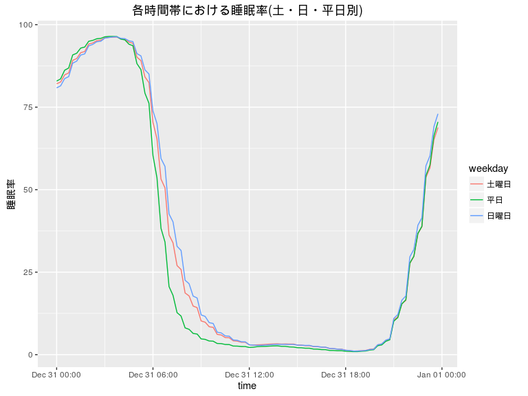

```r
library(ggplot2)
kosaki_weekday <- kosaki %>%
  group_by(time,weekday) %>%
  summarise(value=mean(value))
ggplot(kosaki_weekday, aes(x=time, y=value, color=weekday)) +
  geom_line() +
  labs(title="各時間帯における睡眠率(土・日・平日別)", y="睡眠率")
```

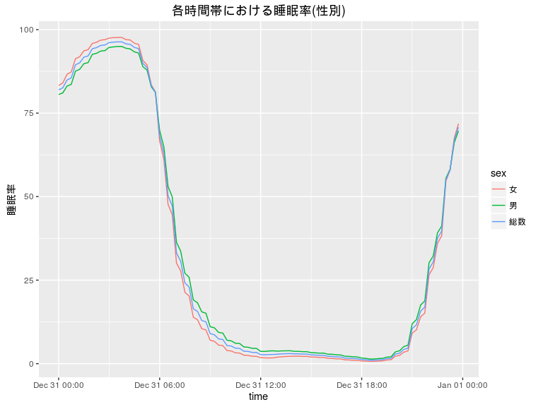

```r
kosaki_fm <- kosaki %>%
  group_by(time,sex) %>%
  summarise(value=mean(value))
ggplot(kosaki_fm, aes(x=time, y=value, color=sex)) +
  geom_line() +
  labs(title="各時間帯における睡眠率(性別)", y="睡眠率")
```

- 本当はdygraphsパッケージ使ってグリグリ動くようにしたかったorz

# Enjoy!

### 参考資料

- [e-Stat APIをRから使うパッケージを作りました - Technically, technophobic.](http://notchained.hatenablog.com/entry/2015/11/01/084909)
- [Rで統計API - 備忘録＠かすみがおか](http://nonki1974.hateblo.jp/entry/2013/06/14/221243)
- [RPubs - 政府統計の総合窓口(e-Stat)のAPIを使ってみよう [R編]](http://rpubs.com/R_Linux/estat?utm_source=twitterfeed&utm_medium=twitter)
- [e-StatのAPI](https://oku.edu.mie-u.ac.jp/~okumura/stat/estat.html)